# Forecasting Methods - Final Project

Author

Kowsalya Muralidharan

**Section 1 - Exploratory Data analysis and Time Series Decomposition**

#### About the Data

```r
library(slider)
library(lubridate)
library(tsibble)
library(dplyr)
library(ggplot2)
library(kableExtra)
library(tidyr)
library(patchwork)
library(lubridate)
library(knitr)
library(fpp3)
library(psych)
library(forecast)
library(urca)
library(data.table)
library(fable)
library(fable.prophet)
library(changepoint)
```

The time series dataset analyzed in the below assignment is Traffic Crash Reports recorded in the event of a Cincinnati Police Department response to a traffic crash, which includes records of data, injury and non-injury crashes. The dataset is updated on a daily basis and is available to the public through the city’s Open Data portal.

The data-generation process is performed by recording the event of CPD responding to a traffic crash. The variation in variable (number of crashes) is reliant on a number of factors - traffic patterns, weather, attention of the rider, road conditions and many more. In my opinion, this is a difficult variable to forecast, owing to the complexity of traffic dynamics and the influence of external factors. Furthermore, having different types of crashes makes it more difficult to predict an identifiable pattern.

```r
accidents <- read.csv("C:\\Users\\kowsa\\Downloads\\cpd_crashes.csv")


accidents$date <- ymd(accidents$date)

accidents_tsbl<- accidents %>%
as_tsibble(index=date) %>%
mutate(date = ymd(accidents$date))


accidents_tsbl
```

```
# A tsibble: 365 x 2 [1D]
   date       cpd_crashes
   <date>           <int>
 1 2023-01-01          81
 2 2023-01-02          31
 3 2023-01-03          69
 4 2023-01-04          77
 5 2023-01-05          66
 6 2023-01-06          53
 7 2023-01-07          75
 8 2023-01-08          52
 9 2023-01-09          58
10 2023-01-10          68
# ℹ 355 more rows
```

The data-frame has been converted to a ‘tsibble’ format to handle date functions. Let’s plot the number of traffic crashes against each day of the year.

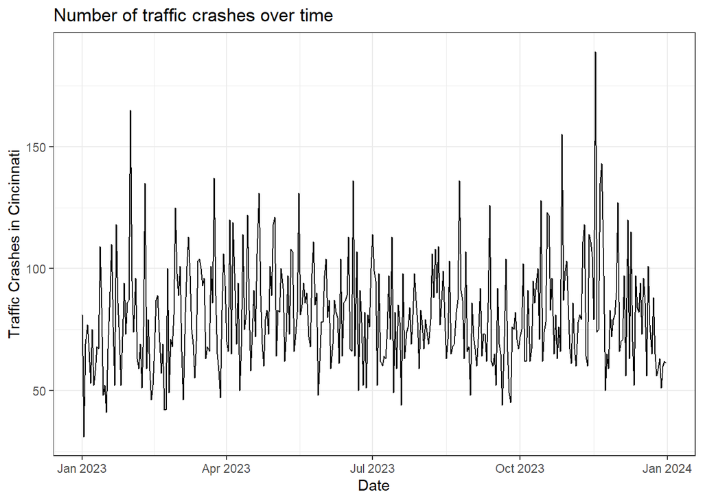

```r
accidents_plot <- accidents_tsbl %>%
  ggplot() +
  geom_line(aes(date, cpd_crashes)) +
  theme_bw() +
  xlab("Date") +
  ylab("Traffic Crashes in Cincinnati") +
  ggtitle("Number of traffic crashes over time")

accidents_plot
```

#### Summary statistics

From the summary statistics below, we can see that the median and mean are not close to each other, suggesting skewness in the data. The maximum value is 189, which seems to be fairly relieving as compared to most other cities.

```r
summary_stat <- round(t(describe(accidents_tsbl$cpd_crashes)),2)

summary_stat <- cbind('Summary Statistics are ' = rownames(summary_stat), summary_stat)
row.names(summary_stat) <- NULL
colnames(summary_stat) <- c('Summary Statistics','Value')
summary_stat[-c(1,12),]  %>%
  kbl(align=rep('c', 2)) %>%
  kable_styling()
```

| Summary Statistics | Value |
| --- | --- |
| n | 365 |
| mean | 80.74 |
| sd | 21.99 |
| median | 78 |
| trimmed | 79.06 |
| mad | 19.27 |
| min | 31 |
| max | 189 |
| range | 158 |
| skew | 0.96 |
| se | 1.15 |

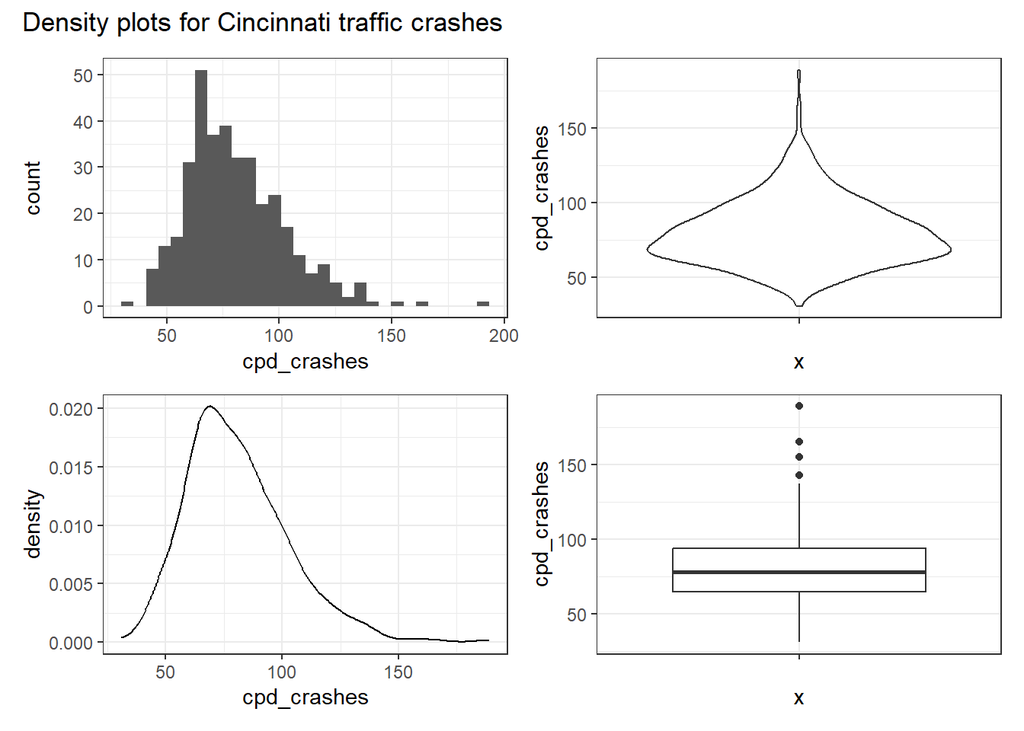

```r
hist <- accidents_tsbl %>%
  ggplot() +
  geom_histogram(aes(cpd_crashes)) +
  theme_bw()

dens <- accidents_tsbl %>%
  ggplot() +
  geom_density(aes(cpd_crashes)) +
  theme_bw()

violin <- accidents_tsbl %>%
  ggplot() +
  geom_violin(aes("", cpd_crashes)) +
  theme_bw()

boxplot <- accidents_tsbl %>%
  ggplot() +
  geom_boxplot(aes("", cpd_crashes)) +
  theme_bw()

hist + violin + dens + boxplot +  plot_annotation(title = 'Density plots for Cincinnati traffic crashes')
```

- As expected, the histogram above is right-skewed with a long tail, and follows an almost-normal distribution with a sudden peak.
- The density graph also shows a right-tailed normal distribution.
- The box-plot shows a few outliers which may be the reason for skewness in the data.
- From the violin plot, we can infer that there is higher density of traffic crashes around the value 75.
- There seems to be a decrease in the number of traffic crashes lately. However, there does not seem to be a clear trend in the data yet.

Before visualizing moving averages, let’s perform rolling standard deviation to check for the variance trend. From below plot, we can observe that there are multiple peaks and fall, however, there is no increasing or decreasing trend implying an overall constant variance.

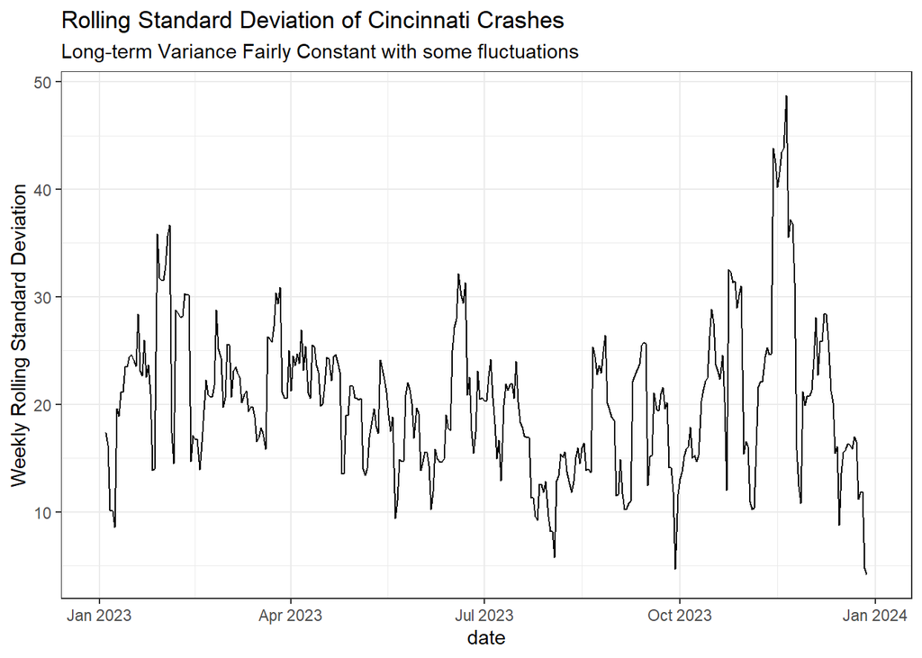

```r
#Rolling standard deviation

accidents_tsbl %>%
mutate(
  sd = slider::slide_dbl(cpd_crashes, sd,.before = 3, .after = 3, .complete = TRUE)
) %>%
ggplot()+
geom_line(aes(date,sd),linewidth=0.5,na.rm=TRUE)+
ggtitle('Rolling Standard Deviation of Cincinnati Crashes',
subtitle = 'Long-term Variance Fairly Constant with some fluctuations')+ theme_bw() +
ylab('Weekly Rolling Standard Deviation')
```

As there are many peaks and valleys, we can perform transformations to reduce the variance in the data. Log transformation has been performed as shown below, and we can see the density curve showing satisfactory results. Hence, we can proceed with the log-transformed value of the number of crashes.

#### Transformations (Log/Box-cox)

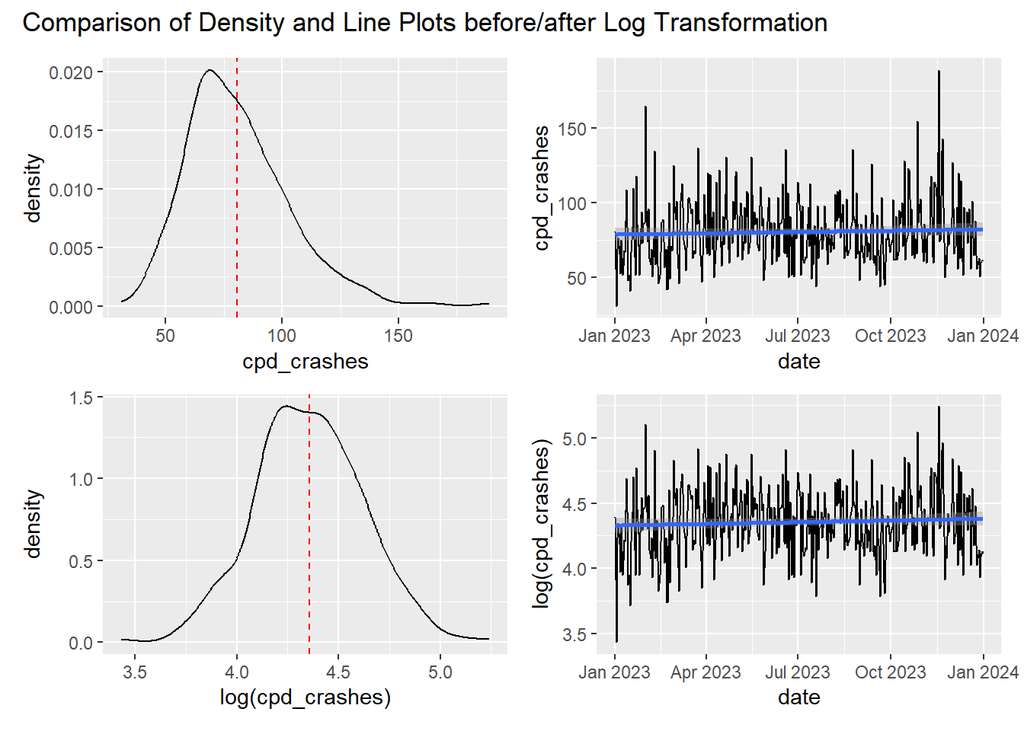

```r
#Performing transformations to reduce variance
density = accidents_tsbl %>%
ggplot()+
geom_density(aes(cpd_crashes))+
geom_vline(aes(xintercept=mean(cpd_crashes)),linetype='dashed',color='red')

line = accidents_tsbl %>%
ggplot()+
geom_line(aes(date,cpd_crashes))+
geom_smooth(aes(date,cpd_crashes),method='lm')

log_density = accidents_tsbl %>%
ggplot()+
geom_density(aes(log(cpd_crashes)))+
geom_vline(aes(xintercept=mean(log(cpd_crashes))),linetype='dashed',color='red')

log_line = accidents_tsbl %>%
ggplot()+
geom_line(aes(date,log(cpd_crashes)))+
geom_smooth(aes(date,log(cpd_crashes)),method='lm')


density + line + log_density + log_line+ plot_layout(ncol = 2, byrow = TRUE) + plot_annotation(title = "Comparison of Density and Line Plots before/after Log Transformation")
```

```r
accidents_tsbl <- accidents_tsbl %>%
mutate(accidents_log = log(cpd_crashes))
accidents_tsbl
```

```
# A tsibble: 365 x 3 [1D]
   date       cpd_crashes accidents_log
   <date>           <int>         <dbl>
 1 2023-01-01          81          4.39
 2 2023-01-02          31          3.43
 3 2023-01-03          69          4.23
 4 2023-01-04          77          4.34
 5 2023-01-05          66          4.19
 6 2023-01-06          53          3.97
 7 2023-01-07          75          4.32
 8 2023-01-08          52          3.95
 9 2023-01-09          58          4.06
10 2023-01-10          68          4.22
# ℹ 355 more rows
```

#### Estimating moving averages

We can now perform moving averages on the log-transformed data. Intuitively, moving average of 7th order would be an ideal choice, given the nature of our data. Let’s plot to compare the moving averages.

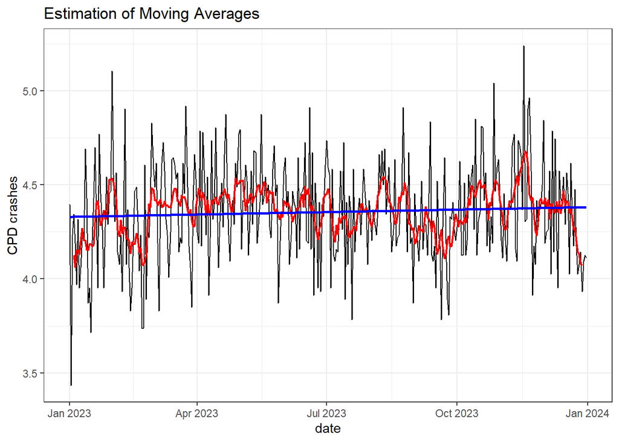

```r
accidents_tsbl_ma <- accidents_tsbl %>%
  arrange(date) %>%
  mutate(
    ma_right = slider::slide_dbl(accidents_log, mean,
                .before = 12, .after = 0, .complete = TRUE),
    ma_left = slider::slide_dbl(accidents_log, mean,
                .before = 0, .after = 12, .complete = TRUE),
    ma_center = slider::slide_dbl(accidents_log, mean,
                .before = 6, .after = 6, .complete = TRUE),
    ma_3 = slider::slide_dbl(accidents_log, mean,
                .before = 1, .after = 1, .complete = TRUE),
    ma_5 = slider::slide_dbl(accidents_log, mean,
                .before = 2, .after = 2, .complete = TRUE),
    ma_7 = slider::slide_dbl(accidents_log, mean,
                .before = 3, .after = 3, .complete = TRUE),
    ma_13 = slider::slide_dbl(accidents_log, mean,
                .before = 6, .after = 6, .complete = TRUE),
    ma_25 = slider::slide_dbl(accidents_log, mean,
                .before = 12, .after = 12, .complete = TRUE),
    ma_49 = slider::slide_dbl(accidents_log, mean,
                .before = 24, .after = 24, .complete = TRUE))


accidents_tsbl_ma_pivot <- accidents_tsbl_ma %>%
  pivot_longer(
    cols = ma_right:ma_49,
    values_to = "value_ma",
    names_to = "ma_order"
  ) %>%
  mutate(ma_order = factor(
    ma_order,
    levels = c(
      "ma_center",
      "ma_left",
      "ma_right",
      "ma_3",
      "ma_5",
      "ma_7",
      "ma_13",
      "ma_25",
      "ma_49"
    ),
    labels = c(
      "ma_center",
      "ma_left",
      "ma_right",
      "ma_3",
      "ma_5",
      "ma_7",
      "ma_13",
      "ma_25",
      "ma_49"
    )
  ))

accidents_tsbl_ma %>%
  ggplot() +
  geom_line(aes(date, accidents_log), linewidth =0.5, color="black") +
  geom_line(aes(date, ma_7), linewidth = 0.75, color = "red") +
  geom_smooth(aes(date, accidents_log), method = "lm", se = F, color = "blue") +
  theme_bw()+
  ylab('CPD crashes')+ ggtitle("Estimation of Moving Averages")
```

Now, let’s plot the moving averages with 7th and 13th order to compare which fits better.

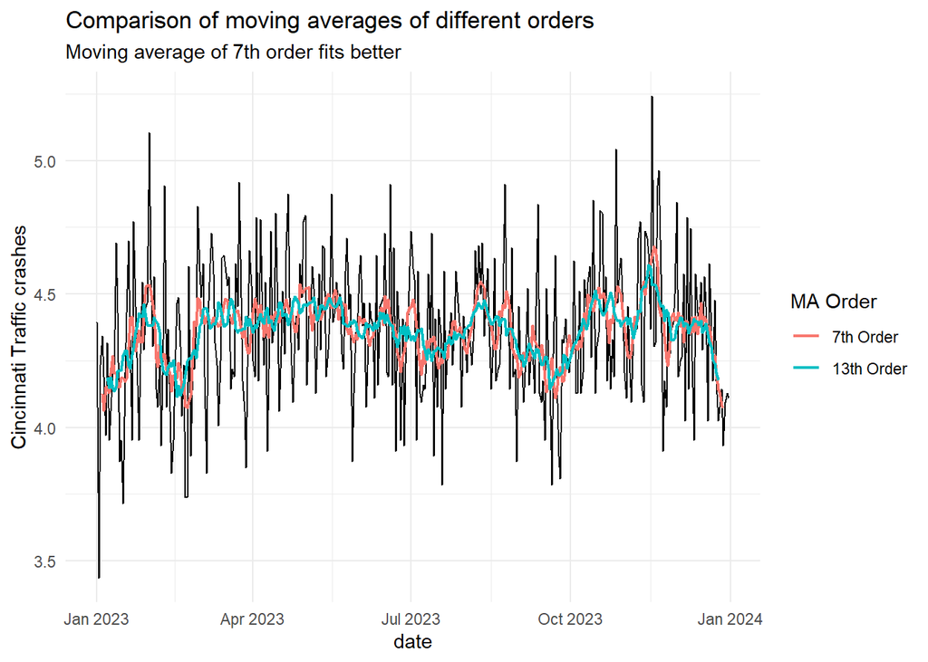

```r
#Moving averages with order
accidents_tsbl_ma_pivot %>%
  filter(
    !ma_order %in% c(
      "ma_center",
      "ma_left",
      "ma_right",
      "ma_3",
      "ma_5",
      "ma_25",
      "ma_49"
    )
  ) %>%
  mutate(ma_order = case_when(
    ma_order=='ma_7' ~ '7th Order',
    ma_order=='ma_13'~'13th Order'

   )
  ) %>%
  mutate(
    ma_order = factor(
      ma_order,
      labels = c(
       '7th Order',
      '13th Order'),

      levels = c(
      '7th Order',
       '13th Order'
     )
    )
  ) %>%
  ggplot() +
  geom_line(aes(date, accidents_log), size = 0.5,na.rm=TRUE) +
  geom_line(aes(date, value_ma, color = ma_order), size = 0.75,na.rm=TRUE,se=F) +
    scale_color_discrete(name = 'MA Order')+
  theme_minimal()+
  ylab('Cincinnati Traffic crashes')+ ggtitle("Comparison of moving averages of different orders",subtitle = "Moving average of 7th order fits better")
```

From the above graph, we can conclude that 7th order Moving average seems to fit the best among all other orders.

#### Performing Linear regression

Now, let’s perform linear regression to fit our data appropriately.

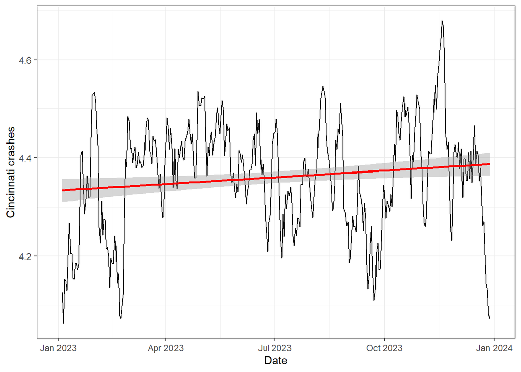

```r
#Linear model
accidents_tsbl_ma %>%
  ggplot() +
  geom_line(aes(date, ma_7)) +
  geom_smooth(aes(date, ma_7), method = "lm", color = "red")+
  theme_bw() +
  xlab("Date") +
  ylab("Cincinnati crashes")
```

```r
accidents_mod <- lm(accidents_log~ date, data = accidents_tsbl)
summary(accidents_mod)
```

```
Call:
lm(formula = accidents_log ~ date, data = accidents_tsbl)

Residuals:
     Min       1Q   Median       3Q      Max
-0.89644 -0.18288 -0.00494  0.18375  0.86609

Coefficients:
             Estimate Std. Error t value Pr(>|t|)
(Intercept) 1.5854224  2.5689978   0.617    0.538
date        0.0001418  0.0001315   1.079    0.282

Residual standard error: 0.2647 on 363 degrees of freedom
Multiple R-squared:  0.003194,  Adjusted R-squared:  0.0004481
F-statistic: 1.163 on 1 and 363 DF,  p-value: 0.2815
```

Since linear model does not really fit our data appropriately, let’s try fitting a polynomial function instead.

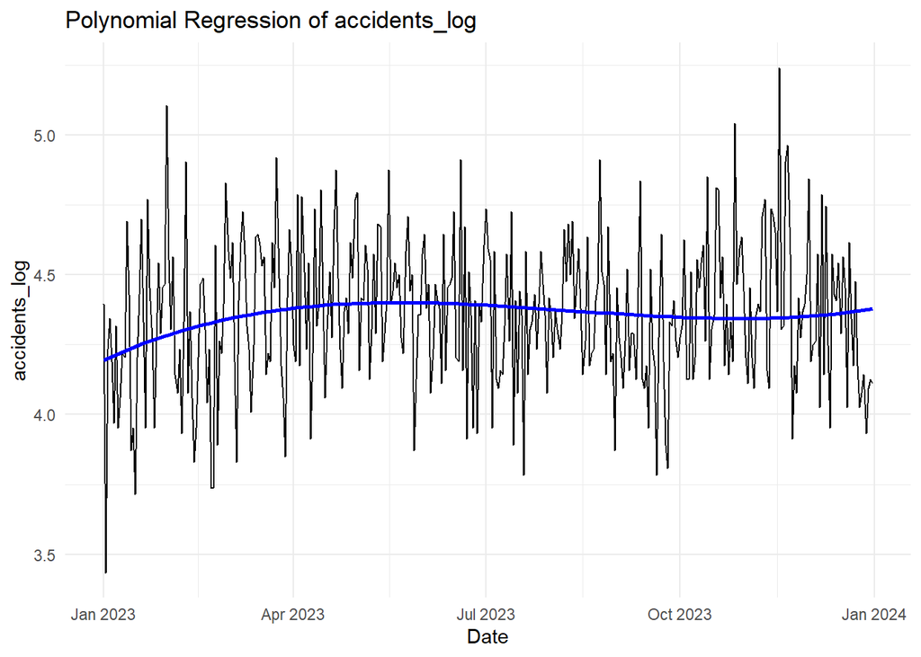

```r
ggplot(accidents_tsbl, aes(x = date, y = accidents_log)) +
  geom_line() +
  # Plot the fitted curve from the polynomial regression model
  geom_smooth(method = "lm", formula = y ~ poly(x, 3), se = FALSE, color = "blue") +
  # Other plot customization options
  labs(title = "Polynomial Regression of accidents_log",
       x = "Date",
       y = "accidents_log") +
  theme_minimal()
```

```r
accidents_mod2 <- lm(accidents_log ~ poly(date,3), data = accidents_tsbl)
summary(accidents_mod2)
```

```
Call:
lm(formula = accidents_log ~ poly(date, 3), data = accidents_tsbl)

Residuals:
     Min       1Q   Median       3Q      Max
-0.76357 -0.18007 -0.00455  0.18142  0.89498

Coefficients:
               Estimate Std. Error t value Pr(>|t|)
(Intercept)     4.35609    0.01373 317.360   <2e-16 ***
poly(date, 3)1  0.28543    0.26223   1.088   0.2771
poly(date, 3)2 -0.60468    0.26223  -2.306   0.0217 *
poly(date, 3)3  0.48454    0.26223   1.848   0.0655 .
---
Signif. codes:  0 '***' 0.001 '**' 0.01 '*' 0.05 '.' 0.1 ' ' 1

Residual standard error: 0.2622 on 361 degrees of freedom
Multiple R-squared:  0.02673,   Adjusted R-squared:  0.01865
F-statistic: 3.305 on 3 and 361 DF,  p-value: 0.02039
```

Let’s calculate the residuals of our fitted model, just to visualize the behaviour. We do not see a particular trend in the residuals.

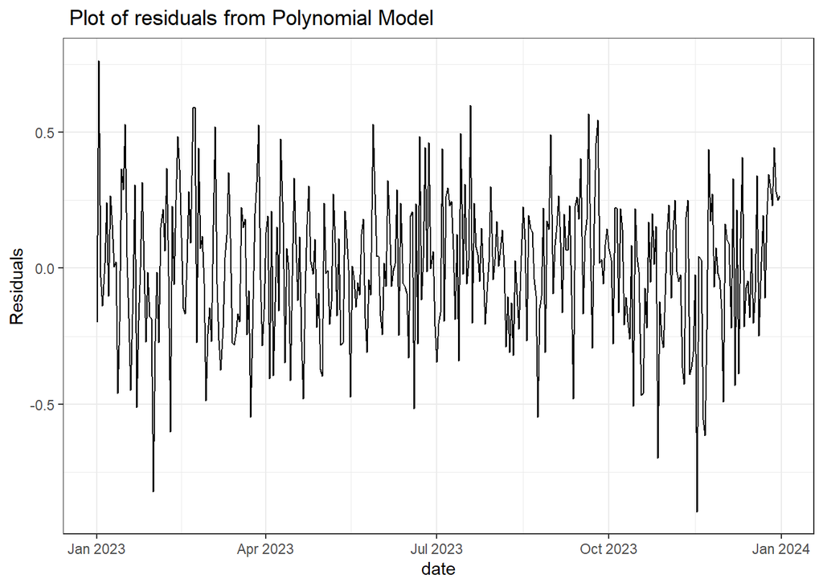

```r
accidents_resid = accidents_tsbl %>%
  mutate(
    pred = predict(accidents_mod2),
    resid = pred - accidents_log
  )

accidents_resid_plot = accidents_resid %>%
  ggplot() +
  geom_line(aes(date, resid),na.rm=TRUE)+
  theme_bw()+
  ylab('Residuals') + ggtitle(" Plot of residuals from Polynomial Model")

accidents_resid_plot
```

#### Classical decomposition

Classical decomposition has been performed for the dataset to separate the trend, seasonality and residuals from the data as seen below. From the remainder component, we can see that there seems to be some seasonality in the data which can be modeled. This is not surprising as we could expect the traffic crashes to be seasonal, especially few days of the week like weekends which could have more traffic.

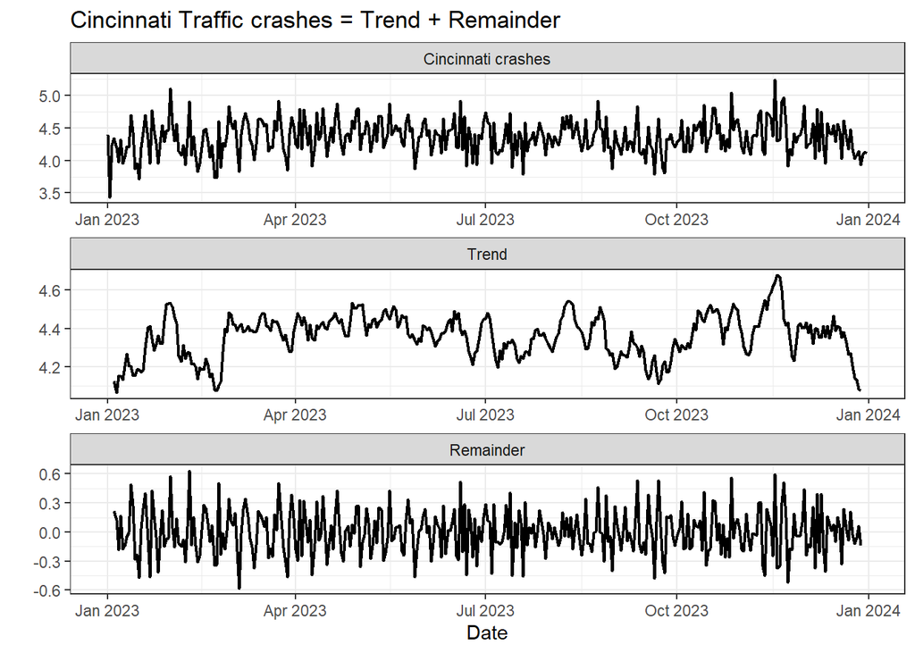

```r
accidents_decomp <- accidents_tsbl %>%
  mutate(
    ma_7 = slider::slide_dbl(accidents_log, mean,
                .before = 3, .after = 3, .complete = TRUE),
  ) %>%
  mutate(resid = accidents_log - ma_7) %>%
  select(date, accidents_log, ma_7, resid)

accidents_decomp_plot <- accidents_decomp %>%
  pivot_longer(
    accidents_log:resid,
    names_to = "decomposition",
    values_to = "accidents_log"
  ) %>%
  mutate(
    decomposition = case_when(
      decomposition == "accidents_log" ~ "Cincinnati crashes",
      decomposition == "ma_7" ~ "Trend",
      decomposition == "resid" ~ "Remainder"
    )
  ) %>%
  mutate(
    decomposition = factor(
      decomposition,
      labels = c(
        "Cincinnati crashes",
        "Trend",
        "Remainder"
      ),
      levels = c(
        "Cincinnati crashes",
        "Trend",
        "Remainder"
      )
    )
  ) %>%
  ggplot() +
  geom_line(aes(date, accidents_log), size = 0.75,na.rm=TRUE) +
  facet_wrap(
    ~decomposition,
    nrow = 3,
    scales = "free"
  ) +
  theme_bw() +
  ylab("") +
  xlab("Date") +
  ggtitle(
    "Cincinnati Traffic crashes = Trend + Remainder"
  )

accidents_decomp_plot
```

For further analysis, let’s plot the additive seasonality to better visualize the decomposition and other trends in the data.

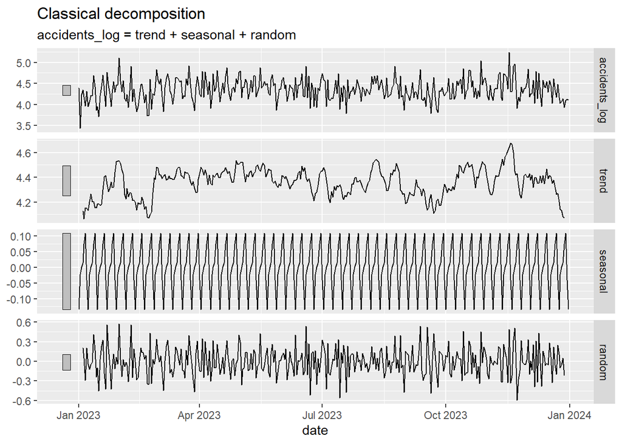

```r
accidents_add = accidents_tsbl %>%
  model(
    classical_decomposition(accidents_log, 'additive')
  ) %>%
  components()

accidents_add%>%
  autoplot()
```

From the lag plots below, we can see that there is negligible seasonality, however we cannot strongly conclude the seasonality based on the decomposition model, as it outputs seasonality even when it is non-existent in the time series. From the below plot, we can presume additive seasonality (however minimum it is).

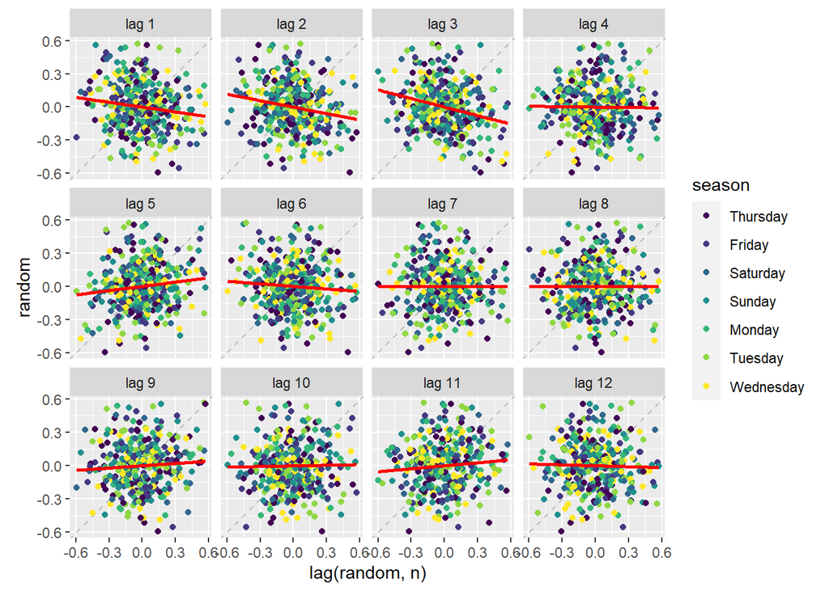

```r
accidents_add %>%
  gg_lag(random, geom = "point", lags = 1:12)+
  geom_smooth(aes(color=NULL),method='lm',color='red',se=F)
```

Multiplicative seasonality plots do not show a significant change from that of additive plot. This shows that whatever seasonality that exists is well described by our additive model.

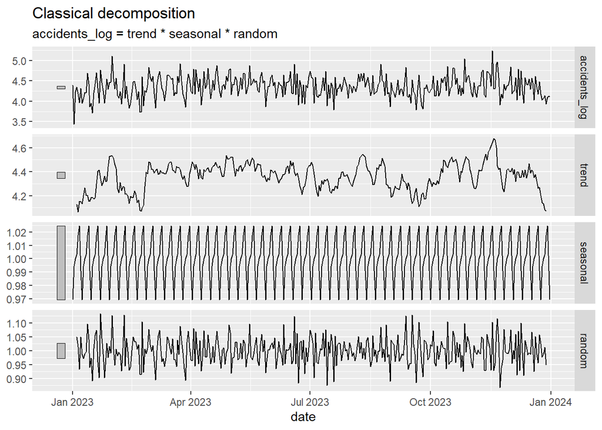

```r
accidents_mul = accidents_tsbl %>%
  model(
    classical_decomposition(accidents_log,'multiplicative')
  ) %>%
  components()

accidents_mul %>%
  autoplot()
```

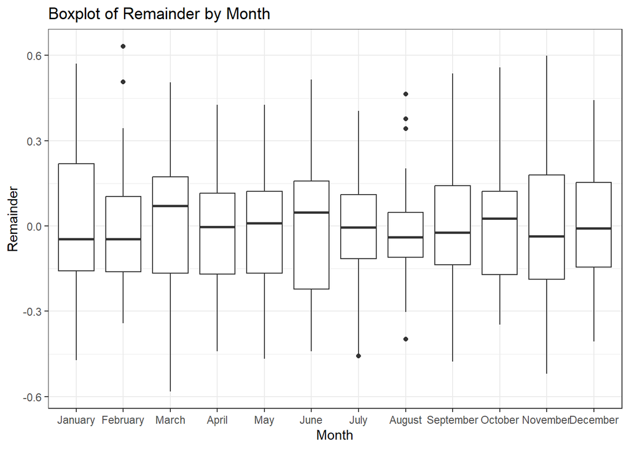

```r
accidents_decomp %>%
  mutate(month = month(date)) %>%
  ggplot() +
  geom_boxplot(aes(factor(month), resid)) +
  theme_bw() +
  ylab('Remainder') +
  xlab('Month') +
  scale_x_discrete(labels = month.name) +
  labs(title = 'Boxplot of Remainder by Month')
```

Since we have only one year of data, let’s see if we can find any weekly seasonality.

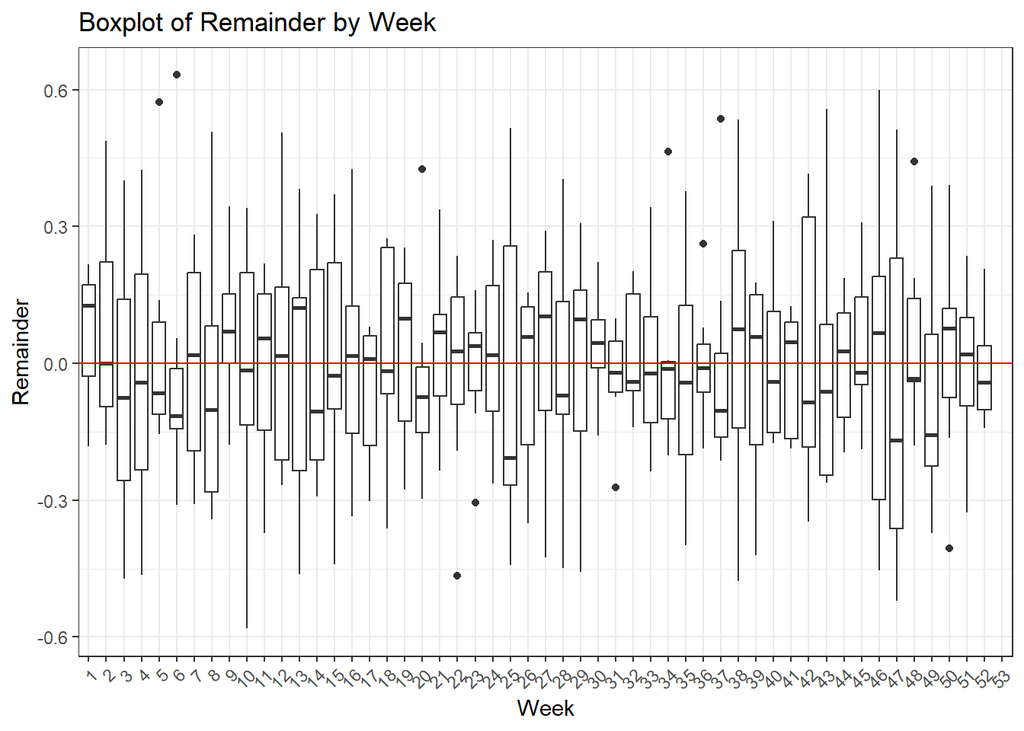

```r
accidents_decomp %>%
  mutate(week = week(date)) %>%
  ggplot() +
  geom_boxplot(aes(factor(week), resid)) +
  theme_bw() +
  ylab('Remainder') +
  xlab('Week') +
  labs(title = 'Boxplot of Remainder by Week') +
    geom_hline(yintercept=0,color='red') +  theme(axis.text.x = element_text(angle = 45, hjust = 1))
```

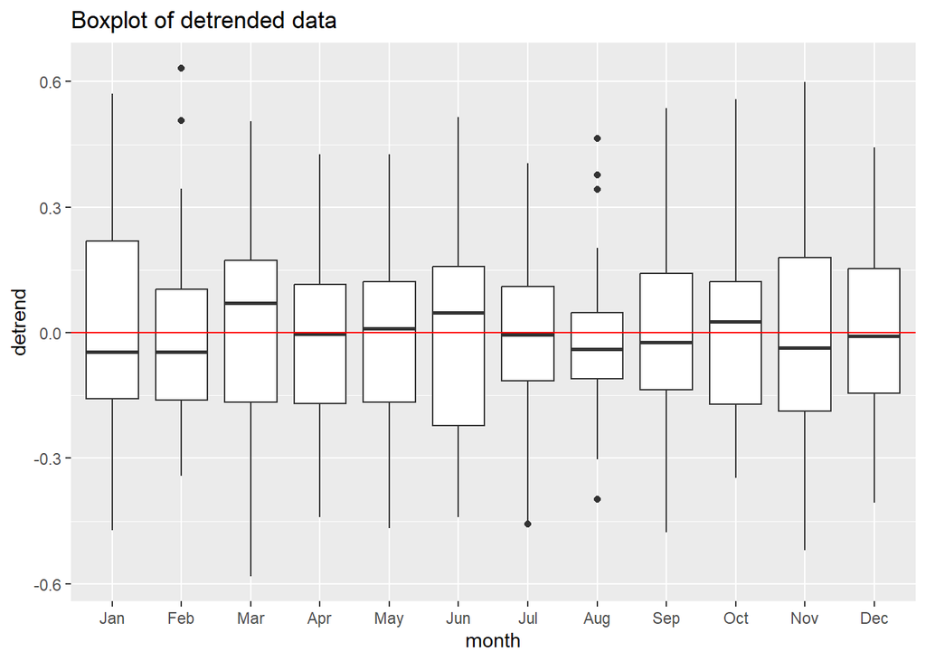

```r
accidents_tsbl %>%
mutate(ma = slider::slide_dbl(accidents_log, mean,
                .before = 3, .after = 3, .complete = TRUE)) %>%
mutate(detrend = accidents_log - ma) %>%
mutate(month = lubridate::month(date,label=T,abbr=T)) %>%
  ggplot()+
  geom_boxplot(aes(month,detrend))+
  geom_hline(yintercept=0,color='red') + ggtitle("Boxplot of detrended data ")
```

From this, we can conclude that there is weekly seasonality in the data and we shall use this feature in our further analysis.

#### Training and Test Data

Let’s split our data into training and test data set for further analysis. Here, 80% of that data has been used for training and the rest for testing purposes.

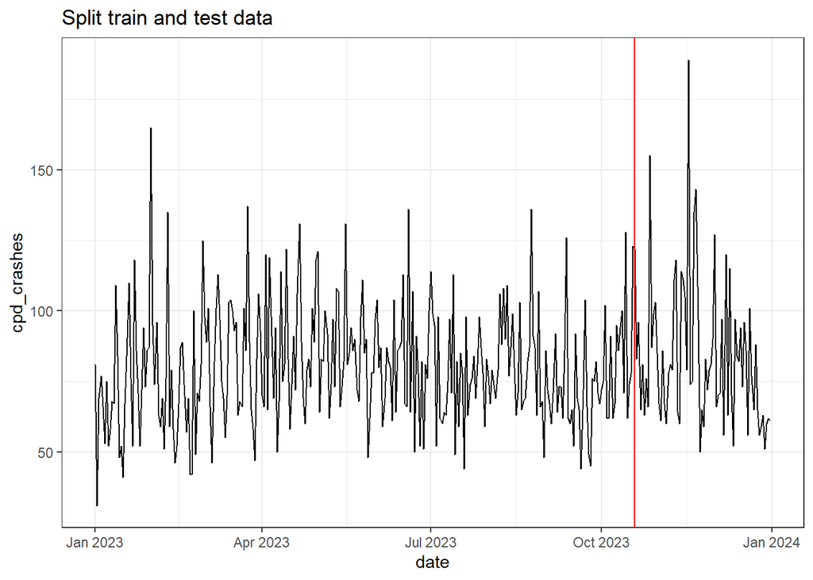

```r
accidents_tsbl %>%
    ggplot()+
    geom_line(aes(date,cpd_crashes))+
    labs(title = 'Split train and test data')+
    geom_vline(aes(xintercept=ymd('2023-10-19')),color='red')+
    theme_bw()
```

```r
train <- accidents_tsbl %>%
  filter(date<ymd('2023-10-19'))

# Test set
test <- accidents_tsbl %>%
  filter(date>=ymd('2023-10-19'))
```

**Section 2 - ARIMA Modeling**

#### Stationarity checks

Now let’s check if our data is mean stationary.

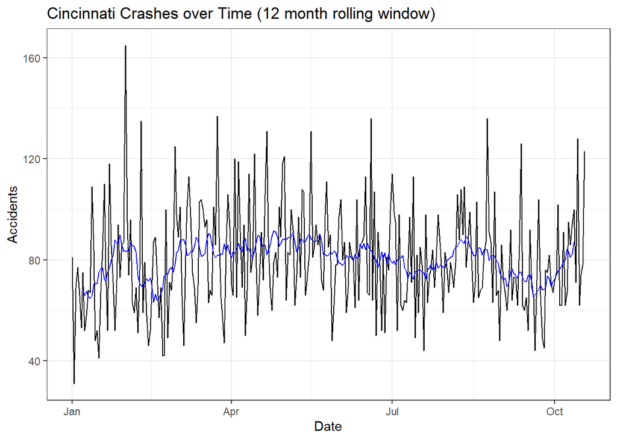

```r
accidents_tsbl_roll <- train %>%
  mutate(
    accidents_mean = slide_dbl(
      cpd_crashes,
      mean,
      .before=6,
      .after=6,
      .complete=T),
    accidents_sd = slide_dbl(
      cpd_crashes,
      sd,
      .before=6,
      .after=6)
  )

accidents_tsbl_roll_mean <- accidents_tsbl_roll %>%
  ggplot() +
    geom_line(aes(date, cpd_crashes)) +
  geom_line(aes(date, accidents_mean),color='blue') +
  theme_bw() +
  ggtitle("Cincinnati Crashes over Time (12 month rolling window)") +
  ylab("Accidents") +
  xlab("Date")

accidents_tsbl_roll_mean
```

It seems to be mean stationary. Let’s conduct the KPSS Test for stationarity.

```r
accidents_diff <- train %>%
  mutate(
    accidents_log = log(cpd_crashes),
    cpd_diff = cpd_crashes - lag(cpd_crashes),
    accidents_log_diff = accidents_log - lag(accidents_log)) %>%
  drop_na() %>%
  as_tsibble(index=date)

# Raw close value - Non-stationary
raw_value_kpss = accidents_diff %>%
features(cpd_crashes, unitroot_kpss)

# First difference - **Non-stationary**
diff_value_kpss = accidents_diff %>%
features(cpd_diff, unitroot_kpss)

# Log close value - Non-stationary
log_value_kpss = accidents_diff %>%
features(accidents_log, unitroot_kpss)

# Differenced log close value - Stationary
log_diff_kpss = accidents_diff %>%
features(accidents_log_diff, unitroot_kpss)

log_value_kpss
```

```
# A tibble: 1 × 2
  kpss_stat kpss_pvalue
      <dbl>       <dbl>
1     0.293         0.1
```

Since the p-value in the KPSS test is > 0.05, we can conclude that the time series is mean stationary. This means we do not need to perform any additional steps to induce mean stationarity in the series.

#### Seasonal differencing

Since our data shows seasonality, let’s perform seasonal differencing.

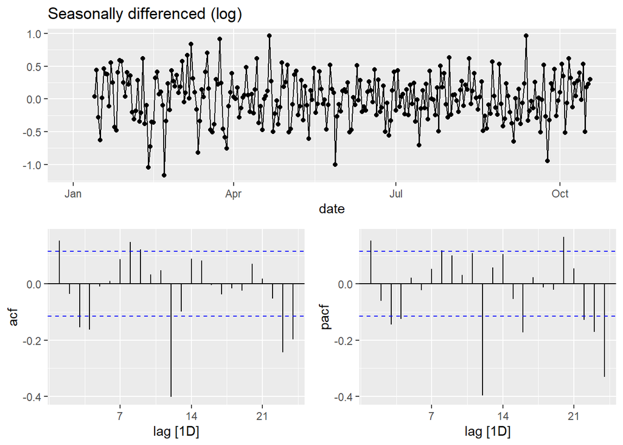

```r
train %>%
  gg_tsdisplay(difference(log(cpd_crashes),12),
               plot_type='partial', lag=24) +
  labs(title="Seasonally differenced (log)", y="")
```

Now, let’s fit our data into ARIMA model on auto ARIMA to see if we get the same result.

```r
# Automatic Differencing using fable
best_mod = train %>%
model(
  mod1 = ARIMA(log(cpd_crashes),approximation=F,stepwise=F) # Takes a while for approximation=F,stepwise=F to run
)

best_mod %>%
report()
```

```
Series: cpd_crashes
Model: ARIMA(2,0,3)(0,0,1)[7] w/ mean
Transformation: log(cpd_crashes)

Coefficients:
          ar1      ar2     ma1     ma2     ma3    sma1  constant
      -0.7860  -0.8473  0.9401  1.0799  0.1935  0.1549   11.4508
s.e.   0.0747   0.0672  0.0987  0.0674  0.0766  0.0592    0.0544

sigma^2 estimated as 0.0645:  log likelihood=-10.86
AIC=37.72   AICc=38.23   BIC=67.11
```

Here, we can see that the best model is ARIMA(2,0,3)(0,0,1). Now let’s build and compare few models.

#### Model building and comparison

```r
models_bic = train %>%
  model(
    mod1 = ARIMA(log(cpd_crashes)~pdq(2,0,3)+ PDQ(0,0,1)),
    mod2 = ARIMA(log(cpd_crashes)~pdq(2,0,2)+ PDQ(0,0,1)),
    mod3 = ARIMA(log(cpd_crashes)~pdq(0,1,2)+ PDQ(0,0,0)),
    mod4 = ARIMA(log(cpd_crashes)~pdq(2,1,1)+ PDQ(0,1,1)),
    mod5 = ARIMA(log(cpd_crashes)~pdq(1,1,2)+ PDQ(0,0,0)),
    mod6 = ARIMA(log(cpd_crashes)~pdq(0,1,2)+ PDQ(0,0,1)),
    mod7= ARIMA(log(cpd_crashes)~pdq(2,0,0)+ PDQ(0,0,1))
  )

models_bic %>%
  glance() %>%
  arrange(BIC)
```

```
# A tibble: 6 × 8
  .model sigma2 log_lik   AIC  AICc   BIC ar_roots  ma_roots
  <chr>   <dbl>   <dbl> <dbl> <dbl> <dbl> <list>    <list>
1 mod3   0.0672   -20.2  46.5  46.5  57.5 <cpl [0]> <cpl [2]>
2 mod7   0.0665   -16.6  43.2  43.4  61.6 <cpl [2]> <cpl [7]>
3 mod5   0.0674   -20.1  48.3  48.4  62.9 <cpl [1]> <cpl [2]>
4 mod1   0.0645   -10.9  37.7  38.2  67.1 <cpl [2]> <cpl [10]>
5 mod2   0.0666   -15.8  45.7  46.0  71.4 <cpl [2]> <cpl [9]>
6 mod4   0.0657   -24.5  59.1  59.3  77.3 <cpl [2]> <cpl [8]>
```

Based on the BIC, Model 3 (0,1,2)(0,0,0) is the best. Hence, we will use this model for our further analysis.

```r
best_model_arima = train %>%
model(
  mod1 = ARIMA(log(cpd_crashes)~pdq(0,1,2)+ PDQ(0,0,0))
)
```

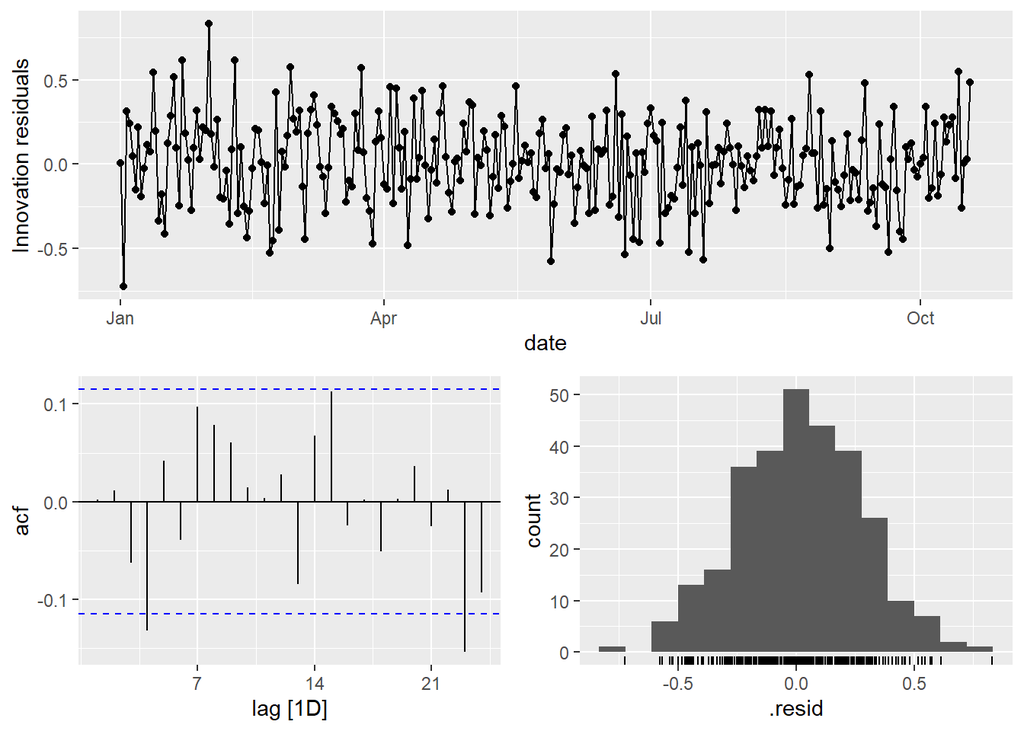

```r
best_model_arima %>%
  gg_tsresiduals()
```

- From the above plot, we can see that the residuals are normally distributed.
- The model is well-fitted as we do not see any significant autocorrelation at lag 1 in the ACF plot.
- There are some seasonal components in the ACF residual plot.

Now, let’s perform the Ljung-Box Test to check for any leftover autocorrelation in the residuals.

```r
best_model_arima %>%
  augment() %>%
  features(.innov, ljung_box, lag = 10, dof = 1)
```

```
# A tibble: 1 × 3
  .model lb_stat lb_pvalue
  <chr>    <dbl>     <dbl>
1 mod1      13.2     0.154
```

- The p-value is > 0.05, indicating that there is not residual auto-correlation and that the residuals are white noise.

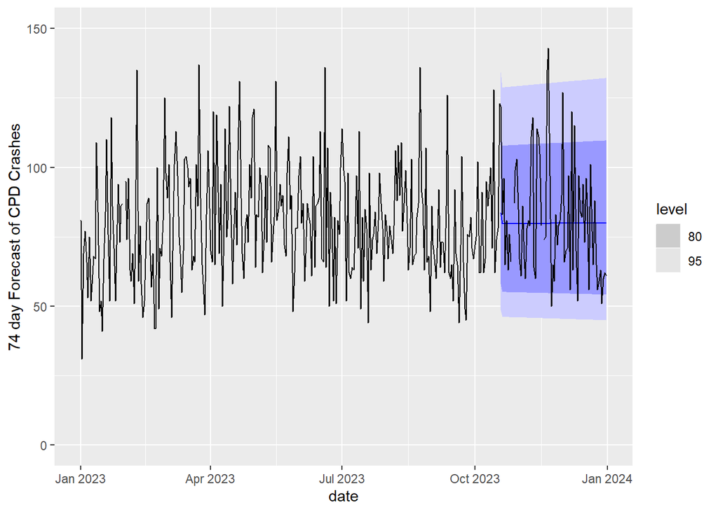

```r
best_model_arima %>%
  forecast(h=74) %>%
  autoplot(accidents_tsbl)+
  ylab('74 day Forecast of CPD Crashes')+
  ylim(0,150)
```

**Section 3 - Meta Prophet Model**

#### Initial Prophet Model

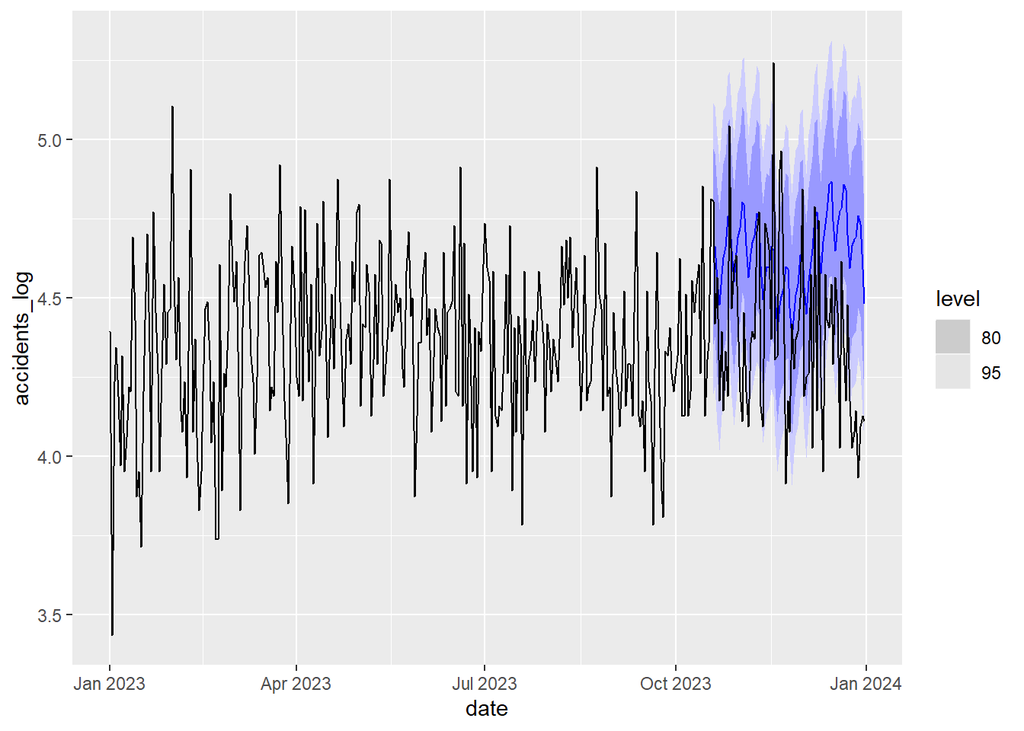

```r
train %>%
model(prophet = fable.prophet::prophet(accidents_log)) %>%
forecast(h=74) %>%
autoplot(accidents_tsbl)
```

By looking at this forecast, we can see that it does not accurately capture the trend. For further analysis, let’s perform time-series decomposition on our model.

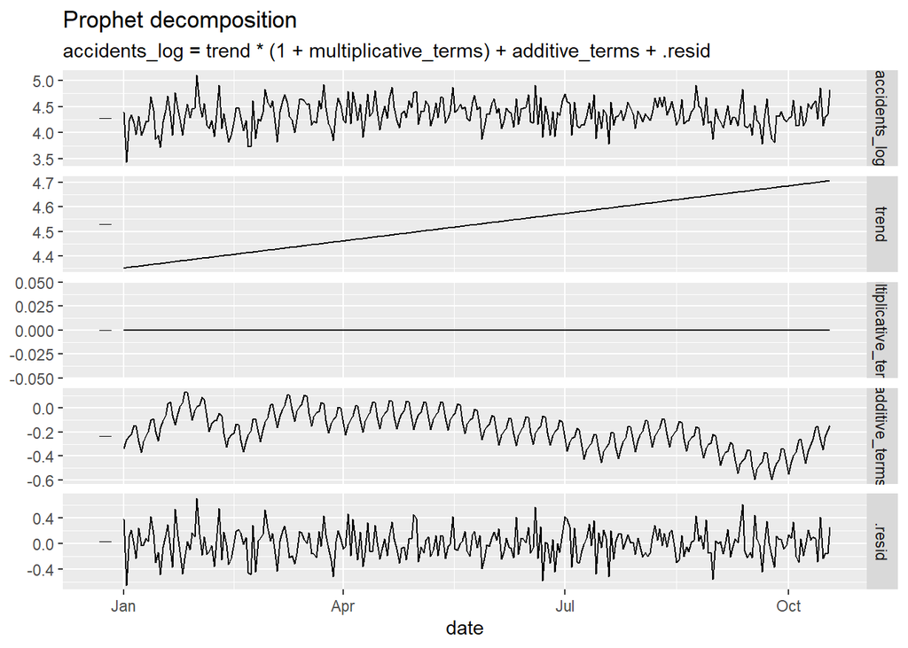

```r
model = train %>%
    model(prophet = fable.prophet::prophet(accidents_log))

model %>%
components() %>%
autoplot()
```

#### Changepoints detection

To detect critical changepoints in our time-series trend, we will first plot automated changepoint detection.

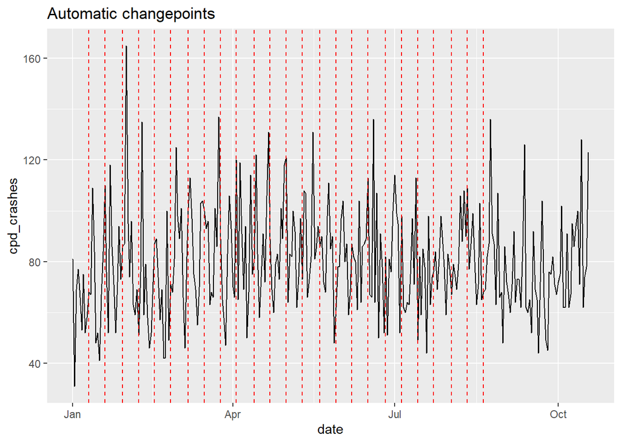

```r
changepoints = model %>%
glance() %>%
pull(changepoints) %>%
bind_rows() %>%
.$changepoints

train %>%
ggplot()+
geom_line(aes(date,cpd_crashes))+
# geom_vline(aes(xintercept=ymd('2000-01-01')))
geom_vline(xintercept=as.Date(changepoints),color='red',linetype='dashed')+
  labs(title = 'Automatic changepoints')
```

- This seems to accurately follow our trend line, but let’s modify some parameters to fine-tune the changepoints parameter. Here, several combinations of changepoints have been tested.
- Based on the information we have for now, let’s set the growth type for our time-series data as ‘linear’.

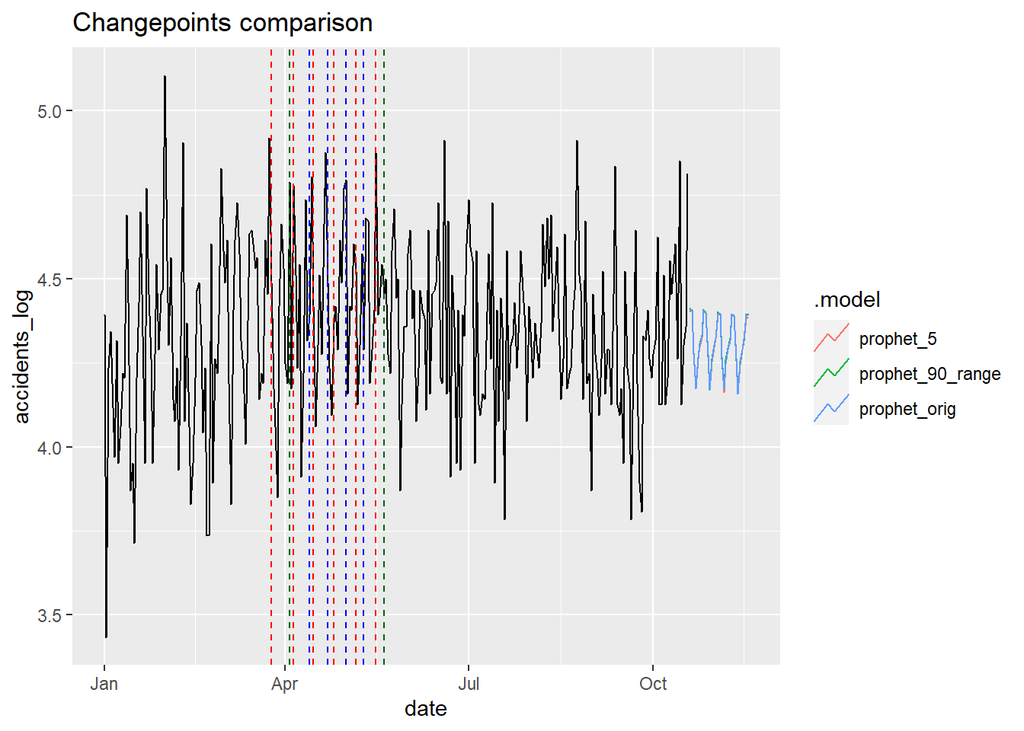

  ```r
  # Number of Changepoints

  model = train %>%
      model(
          prophet_orig = fable.prophet::prophet(accidents_log~growth(type= "linear")+season(period='week')),

          prophet_5 = fable.prophet::prophet(accidents_log~growth(type="linear",n_changepoints=5)+season(period='week')),

      prophet_90_range = fable.prophet::prophet(accidents_log~growth(changepoint_range=0.9)+season(period='week'))
  )

  changepoints_orig = model %>%
  glance() %>%
  filter(.model == 'prophet_orig') %>%
  pull(changepoints) %>%
  bind_rows() %>%
  filter(abs(adjustment)>0.01) %>%
  .$changepoints

  prophet_5 = model %>%
  glance() %>%
  filter(.model == 'prophet_5') %>%
  unnest(changepoints) %>%
  bind_rows() %>%
  filter(abs(adjustment)>=0.01) %>%
  .$changepoints

  changepoints_90_range = model %>%
  glance() %>%
  filter(.model == 'prophet_90_range') %>%
  unnest(changepoints) %>%
  bind_rows() %>%
  filter(abs(adjustment)>=0.01) %>%
  .$changepoints

  model %>%
  forecast(h=30) %>%
  autoplot(train,level=NULL)+
  geom_vline(xintercept=as.Date(changepoints_orig),color='blue',linetype='dashed')+
  geom_vline(xintercept=as.Date(changepoints_90_range),color='red',linetype='dashed') +
  geom_vline(xintercept=as.Date(prophet_5),color='darkgreen',linetype='dashed') +
    labs(title = 'Changepoints comparison')
  ```

It is intuitive that number of crashes cannot be negative. Therefore, it can be said with certainty that our floor value has to be ‘0’. However, to determine the cap value, we need to look at the highest number of crashes throughout the year and intuitively decide on the value. Here, the capacity has been set to 750 and floor to 0.

#### Saturation Model

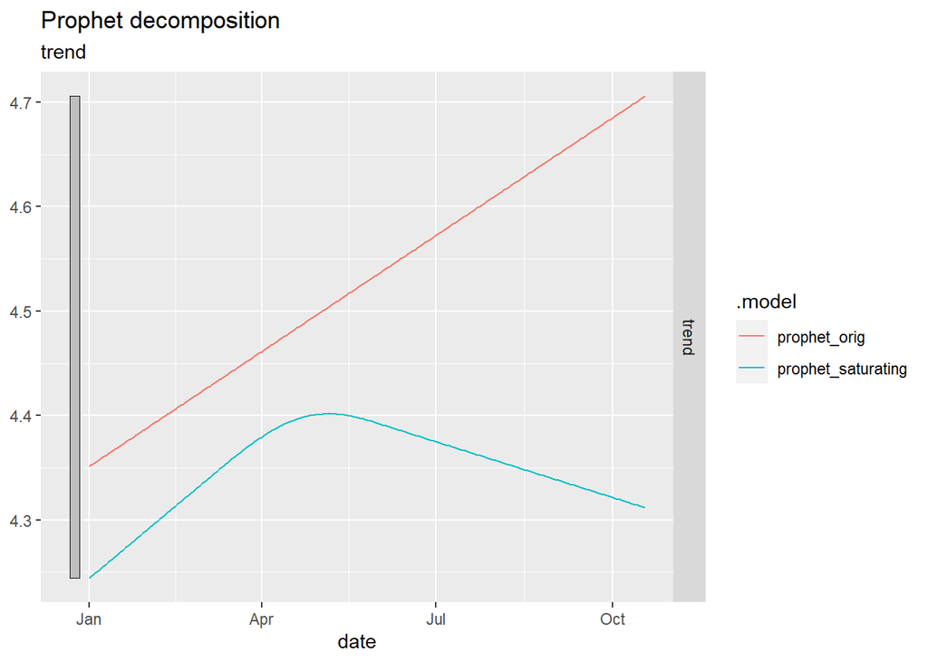

```r
train %>%
    model(
        prophet_orig = fable.prophet::prophet(accidents_log),
        prophet_saturating = fable.prophet::prophet(accidents_log~growth(type='linear',capacity=750,floor=0,changepoint_range=0.9)+season('week'))
        ) %>%
    components() %>%

    autoplot(trend)
```

Based on the trend, we can also conclude that it makes more sense to reduce the number of changepoints to changepoint_range=0.9.

#### Prophet Decomposition

Based on the Prophet decomposition plot, we see that there is some weekly seasonality. Let’s further analyse to identify the seasonal properties of our data.

```r
model = train %>%
    model(prophet = fable.prophet::prophet(accidents_log))

model %>%
components()
```

```
# A dable: 291 x 10 [1D]
# Key:     .model [1]
# :        accidents_log = trend * (1 + multiplicative_terms) + additive_terms
#   + .resid
   .model  date       accidents_log additive_terms multiplicative_terms trend
   <chr>   <date>             <dbl>          <dbl>                <dbl> <dbl>
 1 prophet 2023-01-01          4.39         -0.338                    0  4.35
 2 prophet 2023-01-02          3.43         -0.265                    0  4.35
 3 prophet 2023-01-03          4.23         -0.235                    0  4.35
 4 prophet 2023-01-04          4.34         -0.219                    0  4.35
 5 prophet 2023-01-05          4.19         -0.144                    0  4.36
 6 prophet 2023-01-06          3.97         -0.150                    0  4.36
 7 prophet 2023-01-07          4.32         -0.279                    0  4.36
 8 prophet 2023-01-08          3.95         -0.372                    0  4.36
 9 prophet 2023-01-09          4.06         -0.280                    0  4.36
10 prophet 2023-01-10          4.22         -0.230                    0  4.36
# ℹ 281 more rows
# ℹ 4 more variables: yearly <dbl>, weekly <dbl>, daily <dbl>, .resid <dbl>
```

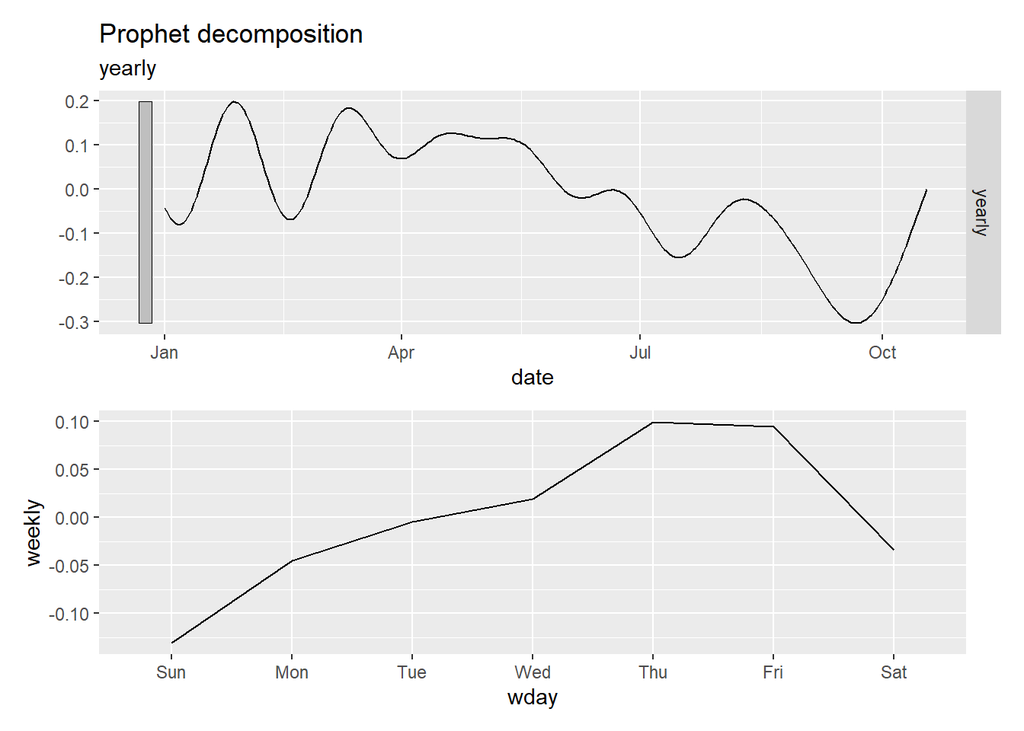

```r
weekly_seasonality = model %>%
components() %>%
as_tibble() %>%
mutate(wday = lubridate::wday(date,label = TRUE,abbr=T)) %>%
group_by(wday) %>%
summarize(weekly = mean(weekly,na.rm=T)) %>%
ungroup() %>%
ggplot()+
geom_line(aes(wday,weekly,group=1))

yearly_seasonality = model %>%
components() %>%
autoplot(yearly)

yearly_seasonality / weekly_seasonality
```

Based on the peaks and troughs in the above plot, we see that our data has some seasonality associated with it. Additionally, we can reiterate that weekly seasonality is present based on the above graphs.

#### Additive vs. Multiplicative

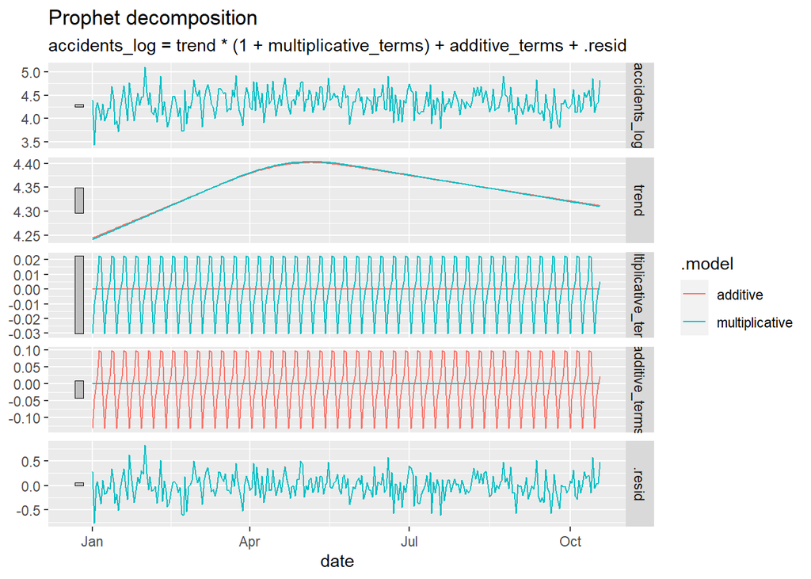

```r
model = train %>%
    model(
      additive = fable.prophet::prophet(accidents_log~growth(type="linear",changepoint_range=0.9,capacity=750,floor=0)+season(period='week',type='additive')),
      multiplicative = fable.prophet::prophet(accidents_log~growth(type="linear",changepoint_range=0.9,capacity=750,floor=0)+season(period='week',type='multiplicative')))

model %>%
components() %>%
autoplot()
```

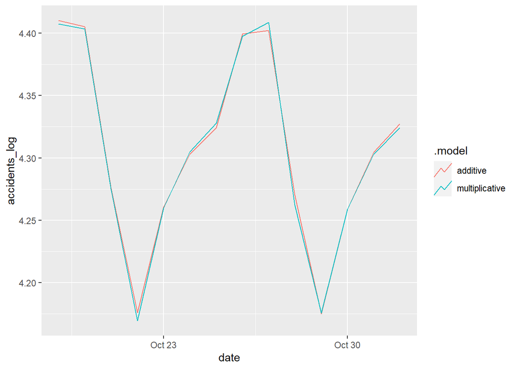

```r
model %>%
forecast(h=14) %>%
autoplot(level=NULL)
```

#### Prophet Holidays

Since we are dealing with daily data, it makes sense to consider the holidays in our dataset.

```r
holidays = tibble(
  holiday = c('Christmas Day','New Year\'s Day','Martin Luther King Jr. Day','Presidents\' Day','Memorial Day','Independence Day','Labor Day','Columbus Day','Veterans Day','Thanksgiving','Washington\'s Birthday',
  'Christmas Day','New Year\'s Day','Martin Luther King Jr. Day','Presidents\' Day','Memorial Day','Independence Day','Labor Day','Columbus Day','Veterans Day','Thanksgiving','Washington\'s Birthday',
  'Christmas Day','New Year\'s Day','Martin Luther King Jr. Day','Presidents\' Day','Memorial Day','Independence Day','Labor Day','Columbus Day','Veterans Day','Thanksgiving','Washington\'s Birthday',
  'Christmas Day','New Year\'s Day','Martin Luther King Jr. Day','Presidents\' Day','Memorial Day','Independence Day','Labor Day','Columbus Day','Veterans Day','Thanksgiving','Washington\'s Birthday',
  'Christmas Day','New Year\'s Day','Martin Luther King Jr. Day','Presidents\' Day','Memorial Day','Independence Day','Labor Day','Columbus Day','Veterans Day','Thanksgiving','Washington\'s Birthday',
  'Christmas Day','New Year\'s Day','Martin Luther King Jr. Day','Presidents\' Day','Memorial Day','Independence Day','Labor Day','Columbus Day','Veterans Day','Thanksgiving','Washington\'s Birthday'),
  Date = ymd(c(
  '2018-12-25','2018-01-01','2018-01-15','2018-02-19','2018-05-28','2018-07-04','2018-09-03','2018-10-08','2018-11-12','2018-11-22','2018-02-19',
  '2019-12-25','2019-01-01','2019-01-15','2019-02-19','2019-05-28','2019-07-04','2019-09-03','2019-10-08','2019-11-12','2019-11-22','2019-02-19',
  '2020-12-25','2020-01-01','2020-01-15','2020-02-19','2020-05-28','2020-07-04','2020-09-03','2020-10-08','2020-11-12','2020-11-22','2020-02-19',
  '2021-12-25','2021-01-01','2021-01-15','2021-02-19','2021-05-28','2021-07-04','2021-09-03','2021-10-08','2021-11-12','2021-11-22','2021-02-19',
  '2022-12-25','2022-01-01','2022-01-15','2022-02-19','2022-05-28','2022-07-04','2022-09-03','2022-10-08','2022-11-12','2022-11-22','2022-02-19',
  '2023-12-25','2023-01-01','2023-01-15','2023-02-19','2023-05-28','2023-07-04','2023-09-03','2023-10-08','2023-11-12','2023-11-22','2023-02-19'))
)

special_holidays = accidents_tsbl %>%
as_tibble() %>%
filter(accidents_log>1250) %>%
select(-accidents_log) %>%
mutate(holiday = paste('holiday',row_number()))

final_holidays = holidays %>%
bind_rows(special_holidays) %>%
distinct(Date,.keep_all=T) %>%
as_tsibble(index=Date)

final_holidays
```

```
# A tsibble: 60 x 4 [1D]
   holiday                    Date       date   cpd_crashes
   <chr>                      <date>     <date>       <int>
 1 New Year's Day             2018-01-01 NA              NA
 2 Martin Luther King Jr. Day 2018-01-15 NA              NA
 3 Presidents' Day            2018-02-19 NA              NA
 4 Memorial Day               2018-05-28 NA              NA
 5 Independence Day           2018-07-04 NA              NA
 6 Labor Day                  2018-09-03 NA              NA
 7 Columbus Day               2018-10-08 NA              NA
 8 Veterans Day               2018-11-12 NA              NA
 9 Thanksgiving               2018-11-22 NA              NA
10 Christmas Day              2018-12-25 NA              NA
# ℹ 50 more rows
```

Let’s perform time-series decomposition on our final model once again after including the holidays.

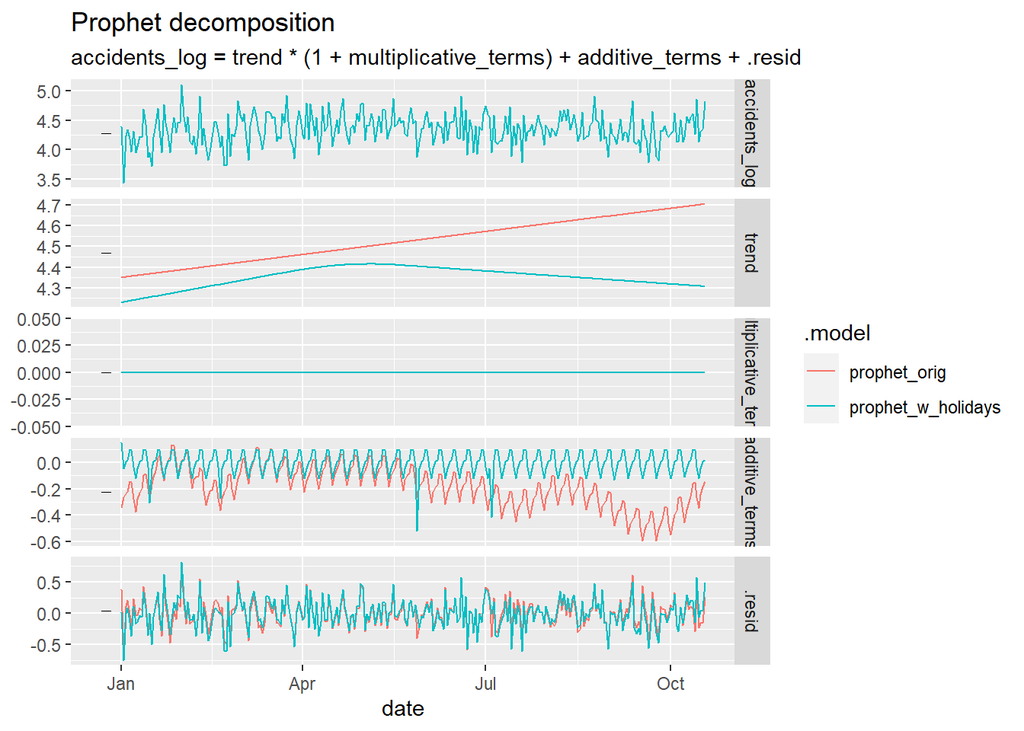

```r
model = train %>%
    model(
      prophet_orig = fable.prophet::prophet(accidents_log),
      prophet_w_holidays = fable.prophet::prophet(accidents_log~growth(type="linear",changepoint_range=0.9,capacity=750,floor=0)+season(period='week',type='additive')+holiday(final_holidays)))

model %>%
components() %>%
autoplot()
```

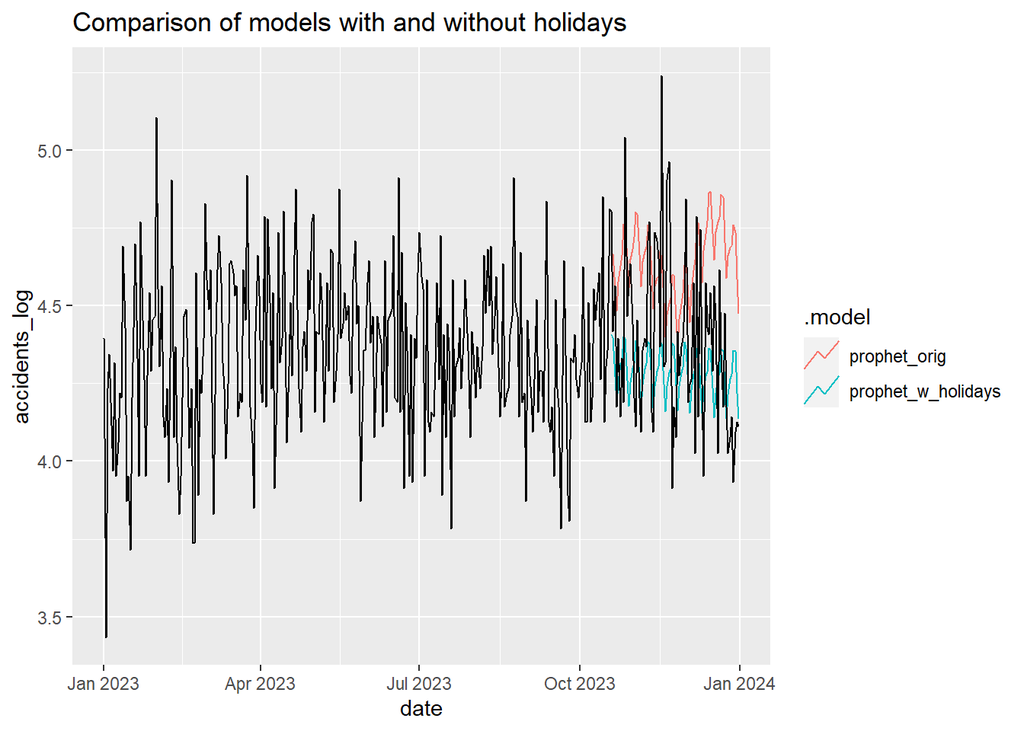

```r
model %>%
forecast(h=365) %>%
autoplot(accidents_tsbl,level=NULL)+
xlim(ymd('2023-01-01'),ymd('2023-12-31'))+labs(title = 'Comparison of models with and without holidays')
```

Upon observing the above plots, we can see that the prophet model with holidays included performs better than the original Prophet model.

**Section 4 - Model Selection and Comparison**

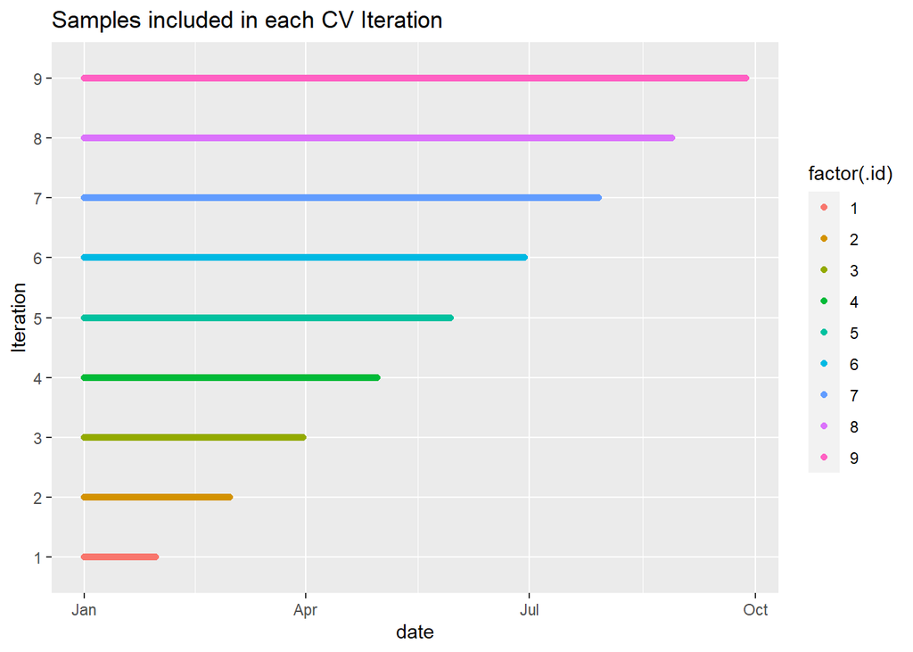

```r
accidents_cv = train %>%
stretch_tsibble(.init=30,.step=30)

accidents_cv %>%
    ggplot()+
    geom_point(aes(date,factor(.id),color=factor(.id)))+
    ylab('Iteration')+
    ggtitle('Samples included in each CV Iteration')
```